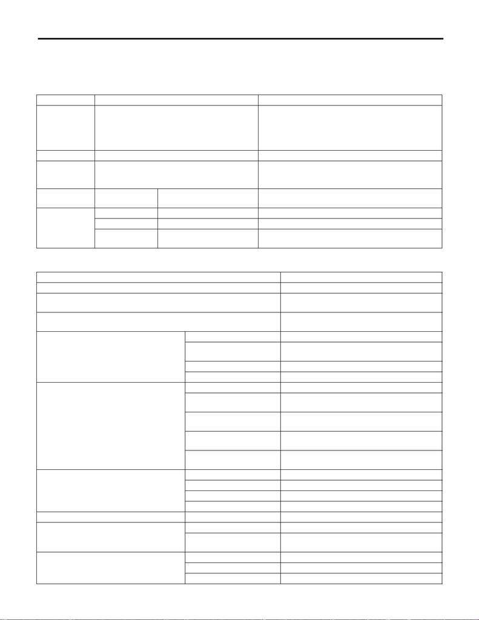

AC-2

General Description

HVAC SYSTEM (HEATER, VENTILATOR AND A/C)

1. General Description

A: SPECIFICATION

1. HEATER SYSTEM

2. A/C SYSTEM

Item Specifications Condition

Heating capacity 5.0 kW (4,299 kcal/h, 17,059 BTU/h) or more

• Air flow control dial or switch: FOOT

• Temperature control dial: HI (MAX HOT)

• Temperature difference between hot water and inlet air:

65°C (149°F)

• Hot water flow rate: 360 L (95.1 US gal, 79.2 Imp gal)/h

Air flow rate 290 m

3

(10,243 cu ft)/h FOOT mode (FRESH), MAX HOT at 12.5 V

Max air flow rate 480 m

3

(16,954 cu ft)/h

• Temperature control dial: LO (MAX COOL)

• Fan dial: HI (MAX): 7th position

• FRESH/RECIRC switch: RECIRC

Heater core

Size

(W × H × T)

257.5 × 118.5 × 27 mm

(10.1 × 4.67 × 1.06 in)

—

Blower motor

Type Magnet motor 300 W or less 12 V

Fan type Sirocco fan type —

Size

(diameter × width)

150 × 75 mm

(5.91 × 2.95 in)

—

Item Specifications

Type of air conditioner Reheat air-mix type

Cooling capacity

5.0 kW

(4,299 kcal/h, 17,059 BTU/h)

Refrigerant

HFC-134a (CH

2

FCF

3

)

[0.475±0.025 kg (1.05±0.06 lb)]

Compressor

Type Rotary fixed capacity

Type

Except for STI model: DKV-10Z

STI model: DKV-10R

Discharge 105 cc (6.41 cu in)/rev

Max. permissible speed 7,700 r/min

Magnet clutch

Type Dry, single-disc type

Power consumption

Except for STI model: 45 W

STI model: 38.8 W

Type of belt

Except for STI model: V-belt 6 PK

STI model: V-belt 4 PK

Pulley dia. (effective dia.)

Except for STI model: 110 mm (4.33 in)

STI model: 100 mm (3.94 in)

Pulley ratio

Except for STI model: 1.3

STI model: 1.32

Condenser

Type Sub cool type

Core face area 0.188 m

2

(2.002 sq ft)

Core thickness 16 mm (0.63 in)

Radiation area 4.5 m

2

(48.44 sq ft)

Expansion valve Type Block

Evaporator

Type Dual-tank

Size

(W × H × T)

290.1 × 172 × 39 mm

(11.42 × 6.77 × 1.54 in)

Blower fan

Fan type Sirocco fan

Outer diameter × Width 150 × 75 mm (5.91 × 2.95 in)

Power consumption 280 W

15WRX_STI_US_EN.book 2 ページ ２０１５年２月１３日 金曜日 午前１１時２０分

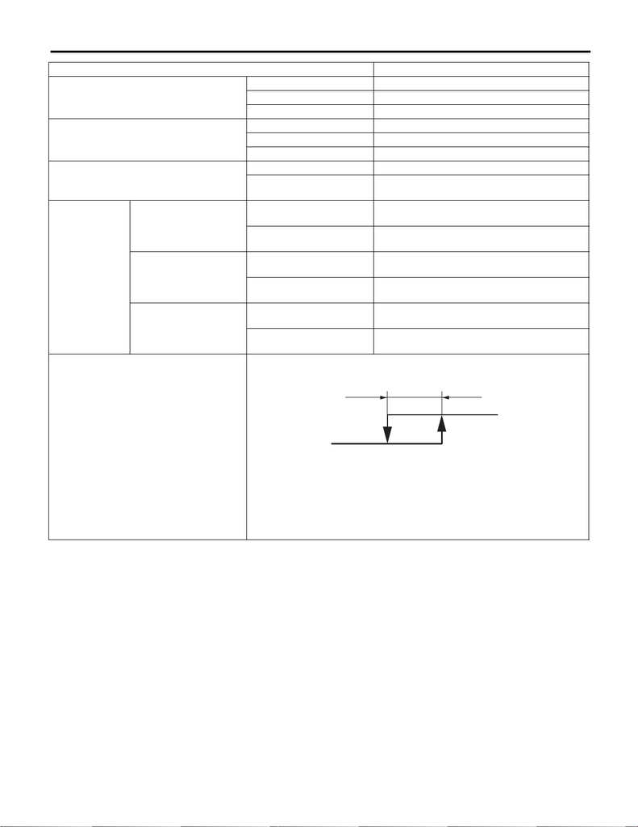

AC-3

General Description

HVAC SYSTEM (HEATER, VENTILATOR AND A/C)

Condenser fan (sub fan)

Motor type Magnet

Power consumption 120 W

Fan outer diameter 318.5 mm (12.5 in)

Radiator fan (main fan)

Motor type Magnet

Power consumption 120 W

Fan outer diameter 318.5 mm (12.5 in)

Idle speed

No load 700±100 r/min

A/C ON

Except for STI model: 700 — 865±50 r/min

STI model: 750±100 r/min

Triple switch

(Pressure switch)

Low-pressure switch

operating pressure

ON → OFF

196±25 kPa

(2.00±0.25 kgf/cm

2

, 28.4±3.6 psi)

OFF → ON

225±30 kPa

(2.29±0.31 kgf/cm

2

, 32.6±4.3 psi)

High-pressure switch

operating pressure

ON → OFF

2,940±200 kPa

(29.98±2.04 kgf/cm

2

, 426.3±29 psi)

OFF → ON

2,350±200 kPa

(24.00±2.04 kgf/cm

2

, 340.7±29.0 psi)

Middle-pressure switch

operating pressure

ON → OFF

1,470±120 kPa

(14.99±1.22 kgf/cm

2

, 213.15±17.4 psi)

OFF → ON

1,770±100 kPa

(18.05±1.02 kgf/cm

2

, 256.65±14.5 psi)

Thermo-control amplifier working temperature

(1) ON

(2) OFF

(3) 1.5±0.3°C (34.7±0.5°F)

(4) 1.0±0.5°C (33.8±0.9°F)

Item Specifications

AC-00601

(1)

(2)

(3)

(4)

15WRX_STI_US_EN.book 3 ページ ２０１５年２月１３日 金曜日 午前１１時２０分

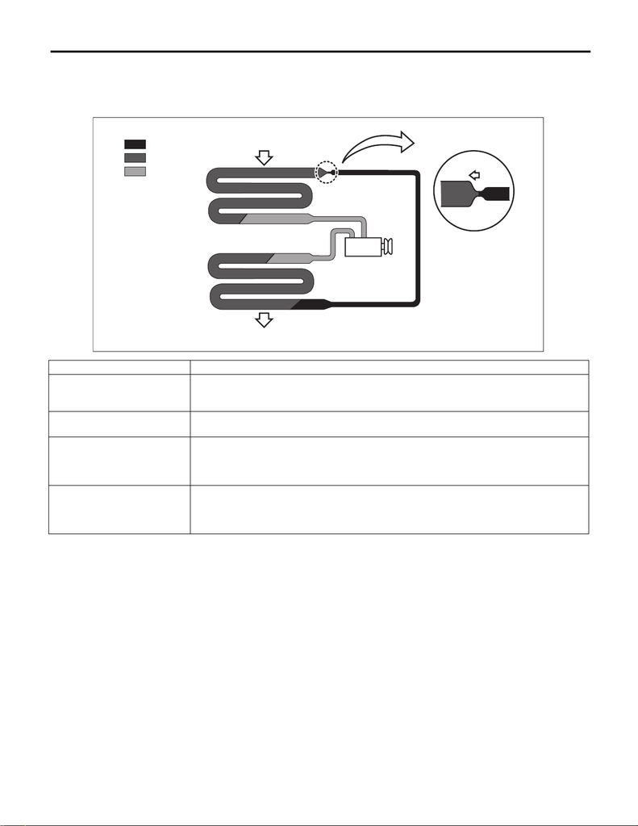

AC-4

General Description

HVAC SYSTEM (HEATER, VENTILATOR AND A/C)

3. BASIC OPERATION

The cooling system cools down the compartment by using the pipes connecting parts and cycling the evap-

orable liquid (refrigerant) within the sealed system in a repeated process of “vaporization — liquefaction —

re-vaporization”.

B: LOCATION

Refer to “Electrical Component Location” for “HVAC SYSTEM (AUTO A/C) (DIAGNOSTICS)” section. <Ref.

to AC(diag)-4, Electrical Component Location.>

Item Operation

Compressor

Sucks and pressurizes the low temperature, low pressure refrigerant gas that was vaporized at

the evaporator by absorbing heat from the compartment, and sends the high temperature, high

pressure refrigerant gas to the condenser.

Condenser

Cools the high temperature, high pressure refrigerant gas sent from the compressor for con-

dense and liquefaction.

Expansion valve

• Sprays the high temperature, high pressure liquid refrigerant from the small hole in order to

let the refrigerant expand rapidly to turn it into low temperature, low pressure mist.

• The refrigerant amount is adjusted according to the refrigerant vaporization condition in the

evaporator.

Evaporator

The evaporator turns into a low temperature condition when the mist refrigerant that was turned

into a low temperature, low pressure condition at the expansion valve is vaporized in large

quantity in the evaporator. Passing air flow through the low temperature evaporator emits cold

air.

AC-02414

: LIQUID

: MIST

: GAS

Heat is removed

Heat is absorbed

COMPRESSOR

CONDENSER

EVAPORATOR

EXPANSION VALVE

LOW

PRESSURE

HIGH

PRESSURE

15WRX_STI_US_EN.book 4 ページ ２０１５年２月１３日 金曜日 午前１１時２０分

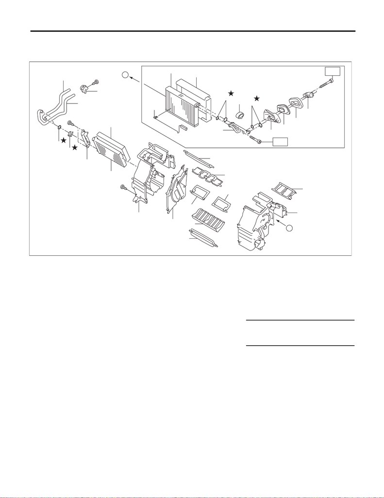

AC-5

General Description

HVAC SYSTEM (HEATER, VENTILATOR AND A/C)

C: COMPONENT

1. HEATER AND COOLING UNIT

(1) Pipe - inlet (11) Shutter - defroster (21) Packing - evaporator core

(2) Pipe - outlet (12) Shutter - vent (22) Pipe - evaporator core

(3) Clamp - pipe (13) Shutter - air mix RH (23) Case - expansion valve

(4) Seal O-ring (14) Shutter - air mix LH (24) Seal - cooling

(5) Clamp (15) Guide - heater unit (25) Packing - heater unit

(6) Plate - heater core (16) Shutter - foot (26) Expansion valve - cooling

(7) Packing - heater core (17) Case - vent duct

(8) Heater core (18) Case - heater unit UPR RH Tightening torque: N·m (kgf-m, ft-lb)

(9) Case - heater unit UPR LH (19) Thermostat - cooling T1: 5 (0.5, 3.7)

(10) Plate CTR (20) Evaporator ASSY - cooling T2: 6.7 (0.7, 4.9)

AC-02786

A

A

(19)

(20)

(21)

(4)

(4)

(21)

(22)

(26)

(23)

(24)

(1)

(3)

(2)

(4)

(5)

(6)

(8)

(9)

(10)

(11)

(12)

(13)

(17)

(18)

(14)

(15)

(16)

(7)

T2

T1

(25)

15WRX_STI_US_EN.book 5 ページ ２０１５年２月１３日 金曜日 午前１１時２０分

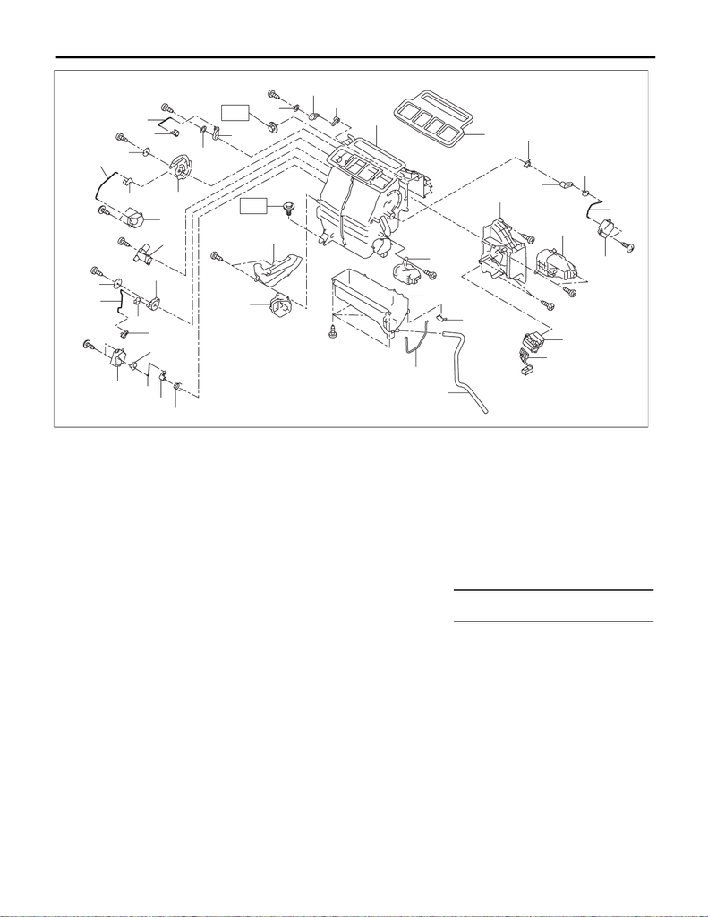

AC-6

General Description

HVAC SYSTEM (HEATER, VENTILATOR AND A/C)

(1) Packing - heater unit (13) Lever - foot sub (25) Spring - heater unit

(2) Case - heater unit (14) Harness - heater unit (26) Lever - air mix

(3) Lever - defroster (15) Cover - heater pipe (27) Rod - air mix

(4) Lever - defroster sub (16) Duct - foot LH (28) Motor - actuator mix RH

(5) Washer - heater (17) Duct - foot RH (29) Rod - mode

(6) Lever - ventilator sub (18) Case - heater LWR (30) Motor - actuator mode

(7) Rod - ventilator (19) Clip - case (31) Aspirator - heater unit

(8) Lever - ventilator door (20) Packing - evaporator cover (32) Motor - actuator mix LH (dual A/C

model)

(9) Lever - mode (21) Hose - drain

(10) Rod - foot (22) Power transistor Tightening torque: N·m (kgf-m, ft-lb)

(11) Clip (23) Cover T: 7.5 (0.8, 5.5)

(12) Lever - foot (24) Cover - heater unit

AC-02788

(1)

(2)

(3)

(4)

(5)

(6)

(7)

(8)

(5)

(5)

(9)

(15)

(17)

(18)

(20)

(19)

(21)

(16)

(22)

(23)

(27)

(28)

(26)

(25)

(24)

(14)

(10)

(11)

(11)

(11)

(11)

(29)

(30)

(31)

(32)

(12)

(13)

(5)

T

T

(25)

(26)

(27)

15WRX_STI_US_EN.book 6 ページ ２０１５年２月１３日 金曜日 午前１１時２０分

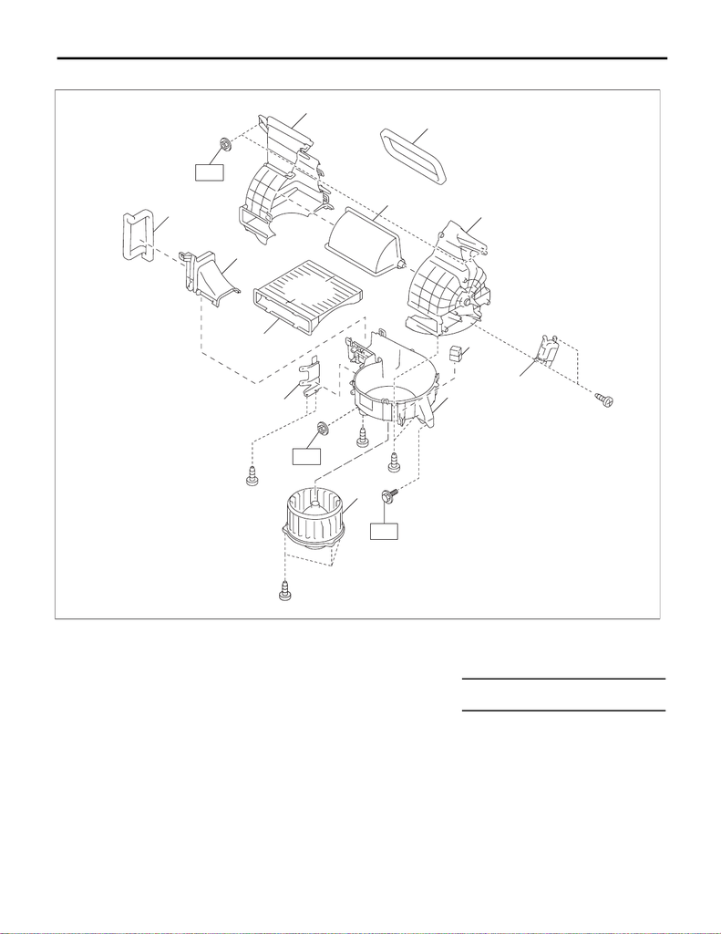

AC-7

General Description

HVAC SYSTEM (HEATER, VENTILATOR AND A/C)

2. BLOWER MOTOR UNIT

(1) Packing (6) Filter kit (11) Case - blower intake RH

(2) Case upper - blower (7) Bracket (12) Motor - actuator blower

(3) Case - blower intake LH (8) Blower - motor

(4) Packing - blower (9) Case lower - blower Tightening torque: N·m (kgf-m, ft-lb)

(5) Shutter - blower (10) Blower motor relay T: 7.5 (0.8, 5.5)

AC-03550

(4)

(11)

(10)

(9)

(6)

(7)

(8)

(3)

(5 )

(1)

(2)

T

T

T

(12)

15WRX_STI_US_EN.book 7 ページ ２０１５年２月１３日 金曜日 午前１１時２０分

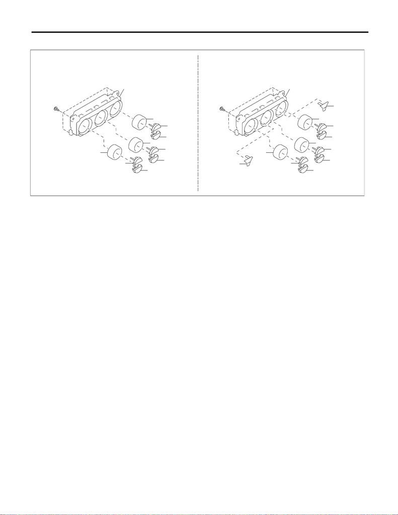

AC-8

General Description

HVAC SYSTEM (HEATER, VENTILATOR AND A/C)

3. CONTROL PANEL

(A) Single A/C model (B) Dual A/C model

(1) Control case (5) Fan dial (9) AUTO switch

(2) Air flow control dial (6) A/C switch (10) Temperature adjustment dial

(3) Defroster switch (7) FRESH/RECIRC switch (11) Air flow control switch

(4) Rear window defogger switch (8) OFF switch (12) Dual switch

AC-03516

(12)

(11)

(A) (B)

(1)

(5)

(8)

(2)

(7)

(6)

(4)

(3)

(10)

(9)

(1)

(5)

(8)

(10)

(7)

(6)

(4)

(3)

(10)

(9)

15WRX_STI_US_EN.book 8 ページ ２０１５年２月１３日 金曜日 午前１１時２０分

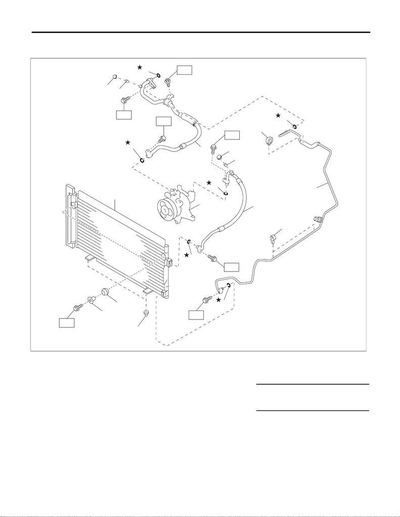

AC-9

General Description

HVAC SYSTEM (HEATER, VENTILATOR AND A/C)

4. AIR CONDITIONING UNIT

• Except for STI model

(1) Cap - hose pressure suction (7) Pipe - evaporator cooling (13) Spacer

(2) Valve - hose pressure (8) Clip - pipe (14) Bushing - condenser

(3) Seal O-ring (9) Hose - pressure discharge

(4) Hose - pressure suction (10) Compressor ASSY Tightening torque: N·m (kgf-m, ft-lb)

(5) Cap - hose pressure discharge (11) Condenser ASSY - air conditioner T1: 7.5 (0.8, 5.5)

(6) Clip (12) Grommet T2: 10 (1.0, 7.4)

(1)

(

4

)

(

3

)

(

3

)

T2

T1

T1

(2)

AC-03517

(11)

(

9

)

(10)

(

2

)

(

8

)

(5)

(

3

)

(

3

)

(

6

)

(

3

)

(

3

)

(12)

(14)

(13)

T1

T1

T1

T2

(

7

)

15WRX_STI_US_EN.book 9 ページ ２０１５年２月１３日 金曜日 午前１１時２０分

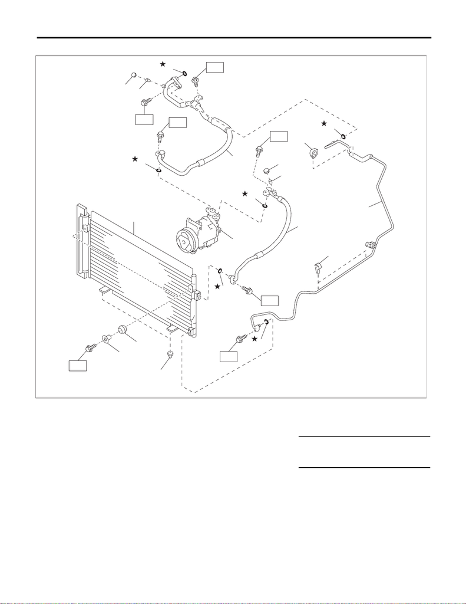

AC-10

General Description

HVAC SYSTEM (HEATER, VENTILATOR AND A/C)

• STI model

(1) Cap - hose pressure suction (7) Pipe - evaporator cooling (13) Spacer

(2) Valve - hose pressure (8) Clip - pipe (14) Bushing - condenser

(3) Seal O-ring (9) Hose - pressure discharge

(4) Hose - pressure suction (10) Compressor ASSY Tightening torque: N·m (kgf-m, ft-lb)

(5) Cap - hose pressure discharge (11) Condenser ASSY - air conditioner T1: 7.5 (0.8, 5.5)

(6) Clip (12) Grommet T2: 10 (1.0, 7.4)

(1)

(

4

)

(

3

)

(

3

)

T2

T1

T2

T1

(2)

AC-03518

(11)

(

9

)

(

2

)

(

8

)

(5)

(

3

)

(

3

)

(

6

)

(

7

)

(

3

)

(

3

)

(10)

(12)

(14)

(13)

T1

T1

T1

15WRX_STI_US_EN.book 10 ページ ２０１５年２月１３日 金曜日 午前１１時２０分

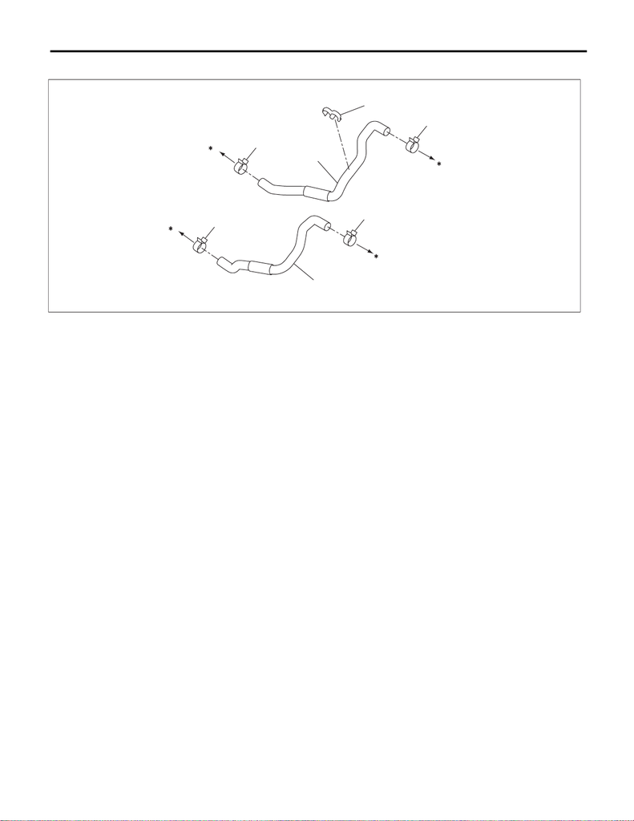

AC-11

General Description

HVAC SYSTEM (HEATER, VENTILATOR AND A/C)

5. HEATER HOSE

(1) Hose - heater outlet (3) Clip (4) Clamp

(2) Hose - heater inlet

*1: Engine side

*2: Heater core side

AC-03381

(2)

(1)

1

1

2

2

(4)

(4)

(4)

(4)

(3)

15WRX_STI_US_EN.book 11 ページ ２０１５年２月１３日 金曜日 午前１１時２０分

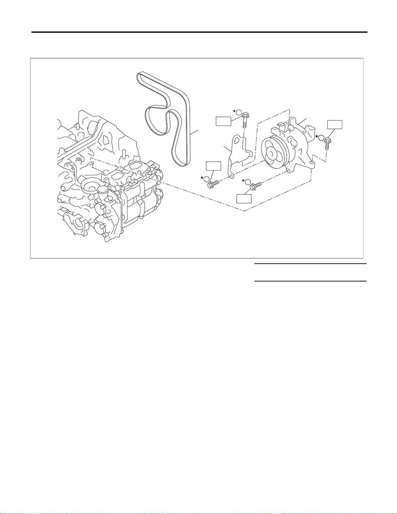

AC-12

General Description

HVAC SYSTEM (HEATER, VENTILATOR AND A/C)

6. COMPRESSOR

• Except for STI model

(1) Compressor ASSY (3) Hanger - engine front Tightening torque: N·m (kgf-m, ft-lb)

(2) V-belt (6 PK) T: 36 (3.7, 26.6)

* Tighten the compressor in the numerical order as shown in the figure.

AC-03494

(

2

)

(

3

)

T

T

T

(

1

)

1

T

2

3

4

15WRX_STI_US_EN.book 12 ページ ２０１５年２月１３日 金曜日 午前１１時２０分

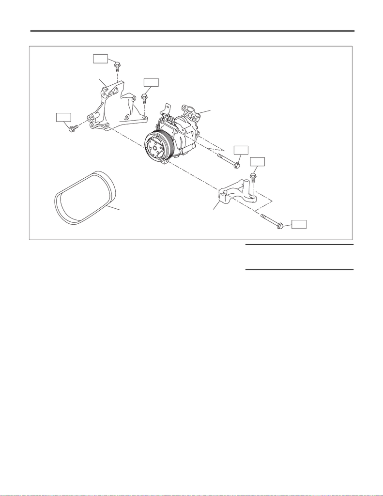

AC-13

General Description

HVAC SYSTEM (HEATER, VENTILATOR AND A/C)

• STI model

(1) Bracket ASSY - compressor (3) V-belt Tightening torque: N·m (kgf-m, ft-lb)

(2) Compressor ASSY (4) Bracket - air conditioner T1: 26.5 (2.7, 19.5)

T2: 36 (3.7, 26.6)

AC-01828

(3)

(2)

(4)

(1)

T1

T1

T2

T2

T2

T2

15WRX_STI_US_EN.book 13 ページ ２０１５年２月１３日 金曜日 午前１１時２０分

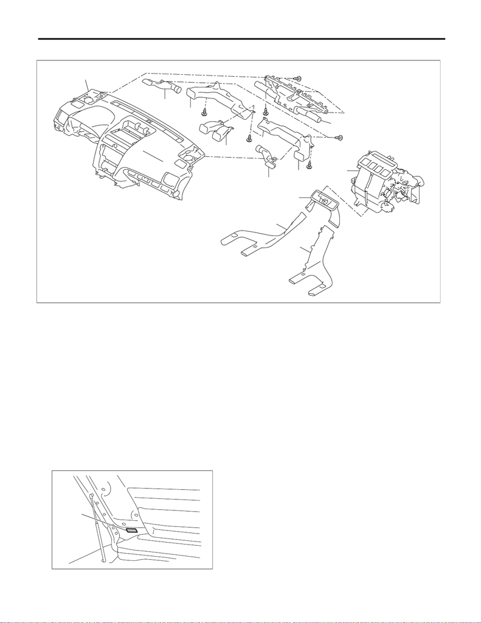

AC-14

General Description

HVAC SYSTEM (HEATER, VENTILATOR AND A/C)

7. HEATER DUCT

D: CAUTION

Before disconnecting connectors of sensors or units, be sure to disconnect the ground cable from battery.

When replacing the audio and MFD parts provided with memory functions, record the memory contents be-

fore disconnecting the battery ground cable.

1. HFC-134A A/C SYSTEM

• The cooling system components for the HFC-134a system using such as the refrigerant and compressor

oil are different from the conventional CFC-12 system components and they are incompatible with each oth-

er.

• Vehicles with the HFC-134a system can be identified by the label (A) attached to the vehicle.

Before maintenance, check A/C system which is installed to the vehicle.

(1) Panel COMPL - instrument (5) Duct - side defroster RH (9) Duct - rear heater LH

(2) Duct - side defroster LH (6) Duct - side ventilation RH (10) Duct - rear heater RH

(3) Duct - side ventilation LH (7) Nozzle - front defroster (11) Heater and cooling unit ASSY

(4) Duct - center vent (8) Duct - rear heater CTR

AC-02678

(1)

(3)

(4)

(5)

(6)

(7)

(2)

(8)

(11)

(9)

(10)

AC-03519

(A)

15WRX_STI_US_EN.book 14 ページ ２０１５年２月１３日 金曜日 午前１１時２０分

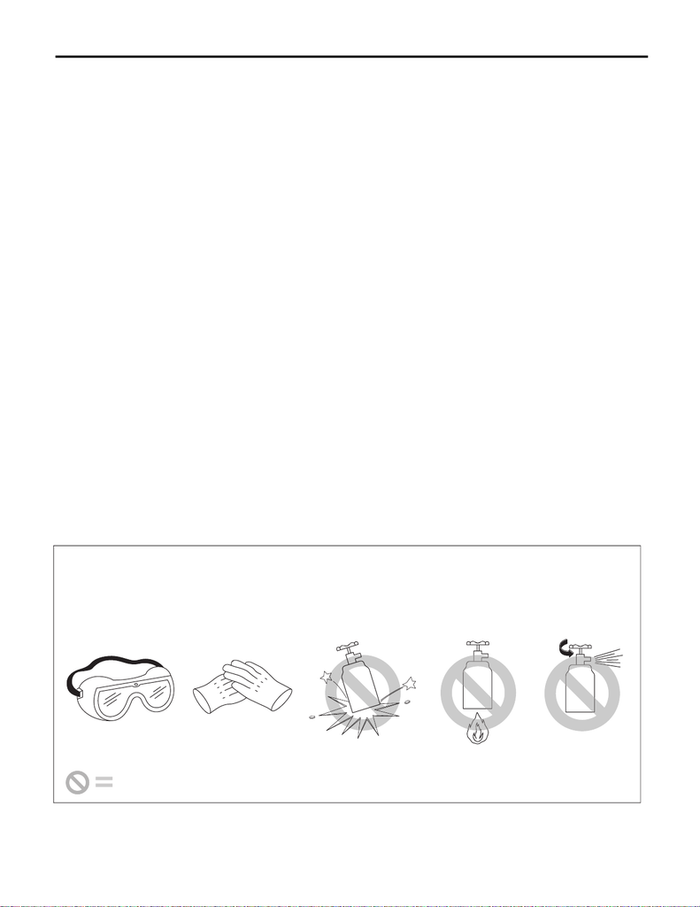

AC-15

General Description

HVAC SYSTEM (HEATER, VENTILATOR AND A/C)

2. COMPRESSOR OIL

• HFC-134a compressor oil has no compatibility with that of CFC-12 system.

• Use only the manufacturer-authorized compressor oil for the HFC-134a system; only use DH-PR

(ZXL200PG).

• Do not mix multiple compressor oils.

If CFC-12 compressor oil is used in the HFC-134a A/C system, the compressor may become stuck due to

poor lubrication, or the refrigerant may leak due to swelling of rubber parts.

On the other hand, if HFC-134a compressor oil is used in a CFC-12 A/C system, the durability of the A/C sys-

tem will be lowered.

• HFC-134a compressor oil is very hygroscopic. When replacing or installing/removing A/C parts, immedi-

ately isolate the oil from atmosphere using a plug or tape. In order to avoid moisture, store the oil in a con-

tainer with its cap tightly closed.

3. REFRIGERANT

• CFC-12 refrigerant cannot be used in a HFC-134a A/C system. HFC-134a refrigerant, also cannot be used

in a CFC-12 A/C system.

• If an incorrect or no refrigerant is used, it will result in poor lubrication and the compressor itself may be

damaged.

4. HANDLING OF REFRIGERANT

• The refrigerant boils at approx. –30°C (–22°F). When handling it, be sure to wear protective goggles and

protective gloves. Direct contact of the refrigerant with skin may cause frostbite.

If the refrigerant gets into your eye, avoid rubbing your eyes with your hands. Wash your eye with plenty of

water, and receive medical treatment from an eye doctor.

• Do not heat a service can. If a service can is directly heated, or put into boiling water, the inside pressure

will become extremely high. This may cause the can to explode. If a service can must be warmed up, use

warm water of 40°C (104°F) or less.

• Do not drop or impact a service can. (Observe the precautions and operation procedure described on the

refrigerant can.)

• When the engine is running, do not open the high-pressure valve of manifold gauge. The high-pressure

gas will back-flow resulting in an explosion of the can.

• Provide good ventilation and do not work in a closed area.

• In order to prevent global warming, avoid releasing HFC-134a into the atmosphere. Using a refrigerant re-

covery system, discharge and recycle the gas.

(A) Goggles (C) Do not apply impact. (E) Do not discharge

(B) Gloves (D) No direct heat on container

AC-02044

(A) (B) (C) (D) (E)

N

G

=

15WRX_STI_US_EN.book 15 ページ ２０１５年２月１３日 金曜日 午前１１時２０分

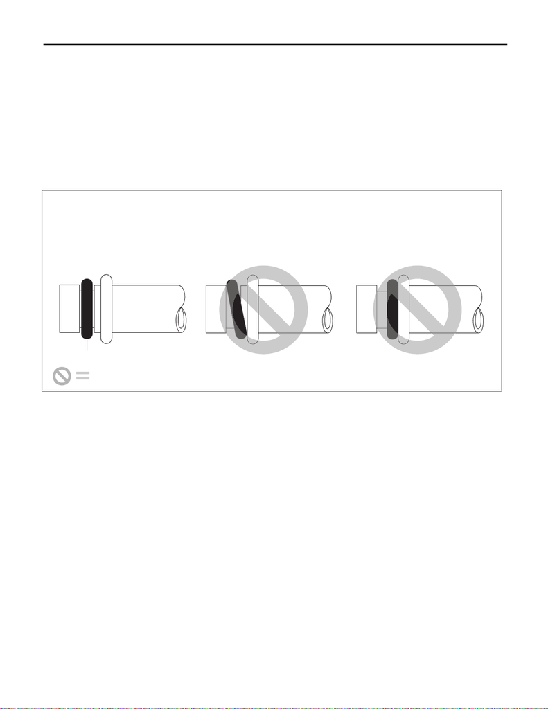

AC-16

General Description

HVAC SYSTEM (HEATER, VENTILATOR AND A/C)

5. O-RING CONNECTIONS

• Always use a new O-ring.

• In order to keep the O-rings free of lint which will cause a refrigerant gas leak, perform work without using

gloves or waste cloths.

• Apply compressor oil to O-rings to avoid sticking, before installation.

• Use a torque wrench to tighten the O-ring fittings. Over-tightening will result in damage of the O-ring and

deformation of the pipe end.

• If the work is interrupted before completing pipe connections, recap the pipes, components and fittings

with a plug or tape to prevent foreign matter from entering.

• Visually check the surfaces and mating surfaces of O-rings, threads and connecting points. If a failure is

found, replace the applicable parts.

• Install the O-rings straight against the pipe groove.

(A) O-ring (B) OK (C) NG

AC-02045

(B)

(A)

(C) (C)

N

G

=

15WRX_STI_US_EN.book 16 ページ ２０１５年２月１３日 金曜日 午前１１時２０分

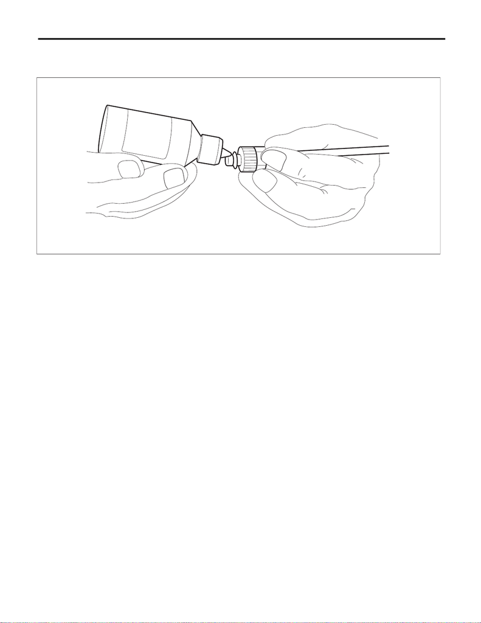

AC-17

General Description

HVAC SYSTEM (HEATER, VENTILATOR AND A/C)

• Use compressor oil specified in the service manual to lubricate the O-rings.

Apply oil to the top and sides of O-rings before installation.

Apply compressor oil to the pipe grooves.

• After tightening, use a clean cloth to remove excess compressor oil from the connections and any oil which

may have run on the vehicle body or other parts.

• If any leakage is suspected after tightening, do not tighten the connections further, but disconnect the con-

nections, remove the O-rings, and check the O-rings, threads, and connections.

AC-02046

15WRX_STI_US_EN.book 17 ページ ２０１５年２月１３日 金曜日 午前１１時２０分

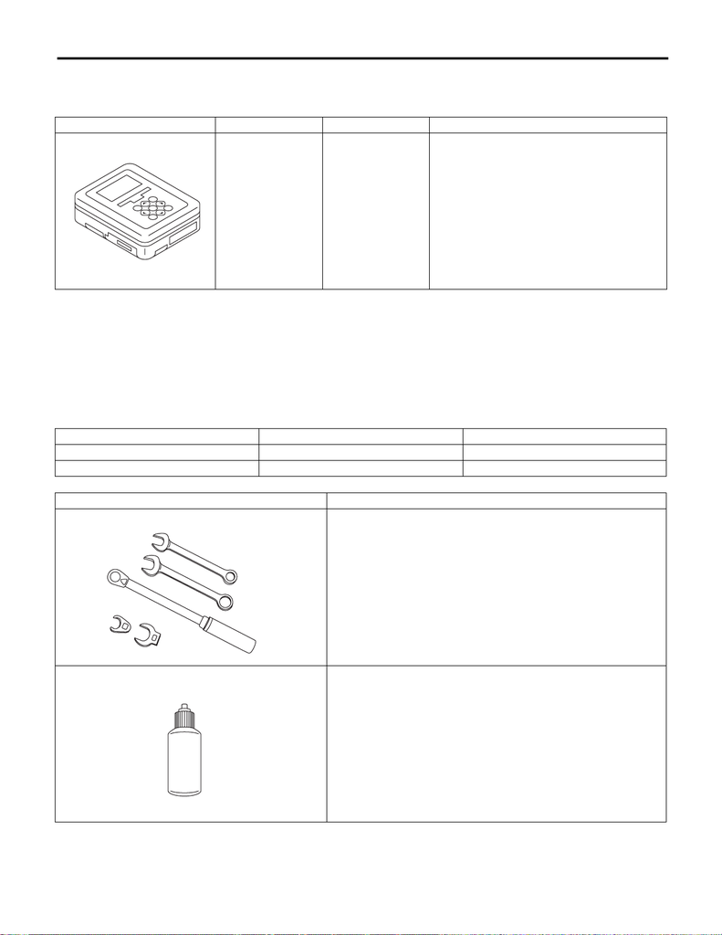

AC-18

General Description

HVAC SYSTEM (HEATER, VENTILATOR AND A/C)

E: PREPARATION TOOL

1. SPECIAL TOOL

2. GENERAL TOOL

CAUTION:

When working on vehicles with a HFC-134a system, only use HFC-134a specified tools and parts. Do

not mix CFC-12 tools and parts. If HFC-134a and CFC-12 refrigerant or compressor oil is mixed, it will

result in poor lubrication and the compressor itself may be damaged.

In order to prevent the mixture of HFC-134a and CFC-12 parts and liquid, the type of tool and screw,

and the replacement valves used are different. The gas leak detectors for the HFC-134a and CFC-12

systems must also not be interchanged.

ILLUSTRATION TOOL NUMBER DESCRIPTION REMARKS

1B022XU0 SUBARU SELECT

MONITOR III KIT

Used for troubleshooting the electrical system.

NOTE:

For detailed operation procedures of SUBARU

SELECT MONITOR III KIT, refer to “PC applica-

tion help for Subaru Select Monitor”.

HFC-134a CFC-12

Tool & screw type Millimeter size Inch size

Valve type Quick joint type Screw-in type

Illustration Tools and Equipment

Wrench

Various WRENCHES will be required to service any A/C system.7 —

40 N·m (0.7 to 4.1 kgf-m, 5 to 30 ft-lb) torque wrench and various crow-

foot wrenches will be needed. Open end or flare nut wrenches will be

needed to affix the pipe and hose fittings.

Applicator bottle

A small APPLICATOR BOTTLE is recommended to apply compressor

oil to the various parts. It can be available at a hardware store.

ST1B022XU0

AC-00213

AC-00012

15WRX_STI_US_EN.book 18 ページ ２０１５年２月１３日 金曜日 午前１１時２０分

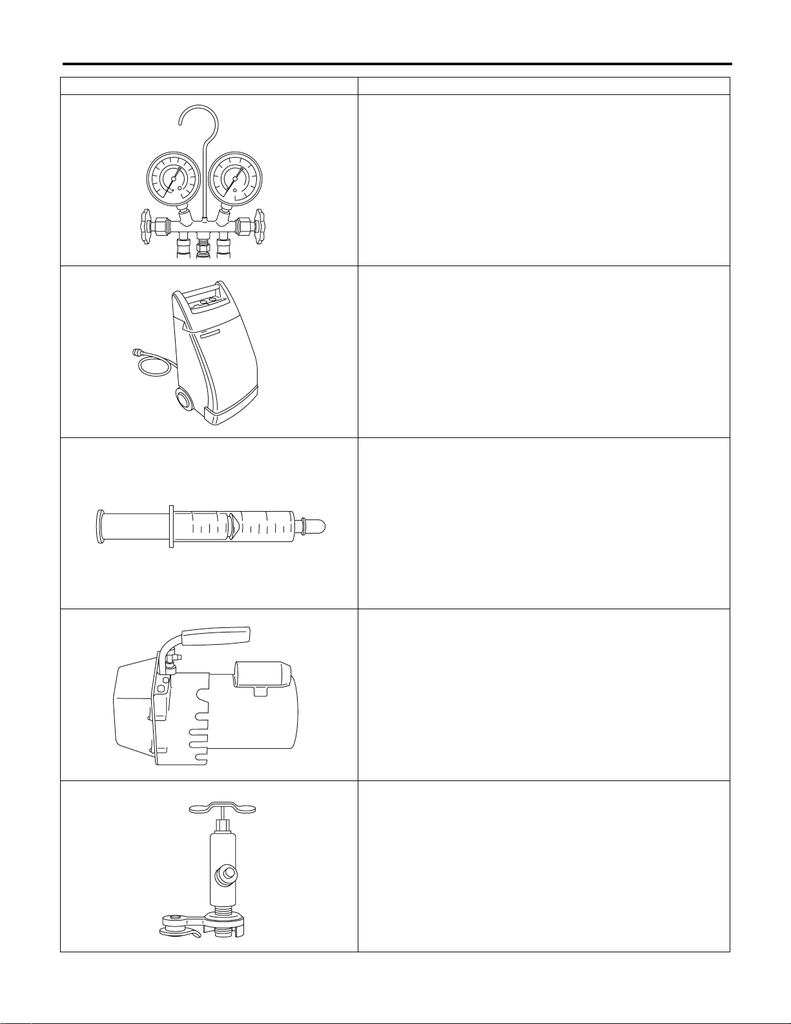

AC-19

General Description

HVAC SYSTEM (HEATER, VENTILATOR AND A/C)

Manifold gauge set

A MANIFOLD GAUGE SET (with hoses) is available at either a refrig-

erant supplier or an automotive equipment supplier.

Refrigerant recovery system

A REFRIGERANT RECOVERY SYSTEM is used for the recovery and

recycling of A/C system refrigerant after contaminants and moisture

have been removed from the refrigerant.

Syringe

A graduated plastic SYRINGE will be needed to add oil into the system

again. A syringe can be available at a pharmacy or drug store.

Vacuum pump

A VACUUM PUMP is necessary (for a good working condition), and

may be available at either a refrigerant supplier or an automotive

equipment supplier.

Can tap

A CAN TAP for the 397 g (14 oz.) can is available at an automotive

equipment supplier.

Illustration Tools and Equipment

AC-00013

AC-00014

AC-00015

AC-00016

AC-00017

15WRX_STI_US_EN.book 19 ページ ２０１５年２月１３日 金曜日 午前１１時２０分

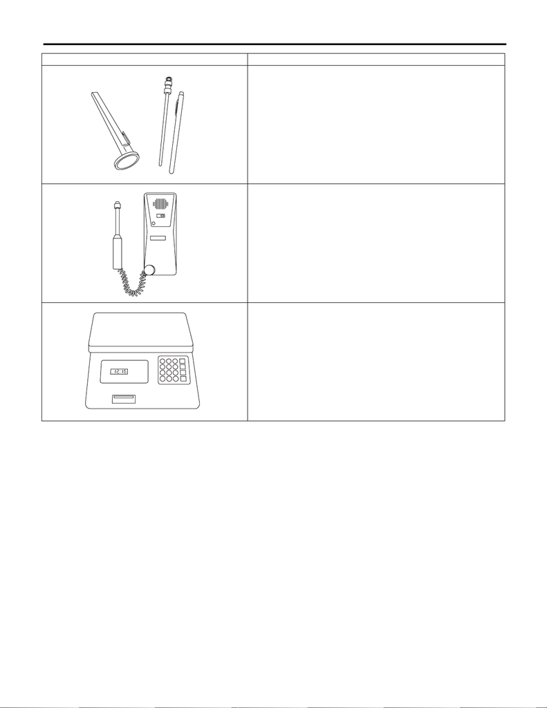

AC-20

General Description

HVAC SYSTEM (HEATER, VENTILATOR AND A/C)

Thermometer

A Pocket THERMOMETER is available at either a industrial hardware

store or a refrigerant supplier.

Electronic leak detector

An ELECTRONIC LEAK DETECTOR can be available at either a spe-

cialty tool supplier or an A/C equipment supplier.

Weight scale

A WEIGHT SCALE such as an electronic charging scale or a bath-

room scale with digital display will be needed, if a 13.6 kg (30 lb) refrig-

erant container is used.

Illustration Tools and Equipment

AC-00018

AC-00019

AC-00020

15WRX_STI_US_EN.book 20 ページ ２０１５年２月１３日 金曜日 午前１１時２０分